# dsp4sh_ref_states2

Katy Dynarski

2024-08-07

# Summary Figures of SOC Stocks

## Summary table of SOC stocks across projects, soils, and treatments

Mean, standard deviation, and n for SOC stocks calculated to 30 cm and 100 cm for all soils in DSP4SH projects.

```r
soc_summary <- soc_pedon %>%
  group_by(project, soil, label) %>%
  summarize(across(soc_stock_0_30cm:soc_stock_100cm, mean_sd), n=n())
flextable(soc_summary)
```

| project | soil | label | soc_stock_0_30cm_mean | soc_stock_0_30cm_sd | soc_stock_30_50cm_mean | soc_stock_30_50cm_sd | soc_stock_50_100cm_mean | soc_stock_50_100cm_sd | soc_stock_100cm_mean | soc_stock_100cm_sd | n |
| --- | --- | --- | --- | --- | --- | --- | --- | --- | --- | --- | --- |
| Illinois | Drummer | BAU | 93.70 | 11.65 | 37.70 | 10.12 | 41.64 | 8.21 | 171.93 | 22.63 | 16 |
| Illinois | Drummer | Ref | 119.64 | 10.55 | 37.61 | 4.60 | 40.08 | 4.83 | 197.33 | 4.03 | 3 |
| Illinois | Drummer | SHM | 91.78 | 22.22 | 31.91 | 11.30 | 75.64 | 72.22 | 203.73 | 81.93 | 6 |
| KansasState | Keith | BAU | 52.75 | 11.65 | 20.28 | 2.99 | 43.26 | 13.67 | 116.29 | 20.80 | 9 |
| KansasState | Keith | Ref | 55.82 | 9.63 | 23.66 | 8.65 | 43.27 | 8.62 | 122.75 | 21.30 | 9 |
| KansasState | Keith | SHM | 38.72 | 4.57 | 16.20 | 2.33 | 34.49 | 6.87 | 89.42 | 6.17 | 6 |
| NCState | Cecil | BAU | 65.22 | 21.26 | 25.77 | 17.56 | 28.02 | 17.89 | 111.81 | 49.24 | 9 |
| NCState | Cecil | Ref | 45.04 | 1.57 | 11.62 | 2.57 | 13.55 | 4.18 | 70.21 | 8.32 | 2 |
| NCState | Cecil | SHM | 56.20 | 17.59 | 17.78 | 5.09 | 19.17 | 4.86 | 92.70 | 20.25 | 9 |
| OregonState | Jory | BAU | 93.50 | 18.58 | 38.54 | 8.02 | 53.36 | 15.40 | 185.40 | 32.87 | 9 |
| OregonState | Jory | Ref | 114.66 | 29.74 | 56.89 | 19.67 | 63.09 | 20.58 | 234.64 | 60.35 | 9 |
| OregonState | Jory | SHM | 79.29 | 17.92 | 37.76 | 12.25 | 65.78 | 22.45 | 182.82 | 48.83 | 9 |
| OregonState | Woodburn | BAU | 64.17 | 17.14 | 22.37 | 11.94 | 27.35 | 12.71 | 113.88 | 41.19 | 9 |
| OregonState | Woodburn | Ref | 67.94 | 17.20 | 22.22 | 8.25 | 22.05 | 6.71 | 112.20 | 26.85 | 9 |
| OregonState | Woodburn | SHM | 69.31 | 8.73 | 21.96 | 5.93 | 32.27 | 5.32 | 123.53 | 17.31 | 9 |
| TexasA&MPt-1 | Amarillo | BAU | 8.07 | 1.41 | 5.33 | 0.72 | 11.82 | 2.02 | 25.21 | 2.97 | 9 |
| TexasA&MPt-1 | Amarillo | Ref | 11.92 | 1.77 | 7.14 | 1.69 | 19.25 | 2.40 | 38.31 | 2.01 | 3 |
| TexasA&MPt-1 | Amarillo | SHM | 12.15 | 1.65 | 5.34 | 1.08 | 13.38 | 3.67 | 30.87 | 5.72 | 18 |
| TexasA&MPt-2 | Pullman | BAU |  |  |  |  |  |  |  |  | 9 |
| TexasA&MPt-2 | Pullman | Ref |  |  |  |  |  |  |  |  | 6 |
| TexasA&MPt-2 | Pullman | SHM |  |  |  |  |  |  |  |  | 9 |
| UConn | Canton | Ref |  |  |  |  |  |  |  |  | 1 |
| UConn | Canton | SHM | 77.16 |  | 38.31 |  |  |  |  |  | 1 |
| UConn | Woodbridge | BAU | 69.00 |  | 10.26 |  | 21.43 |  | 100.68 |  | 1 |
| UConn | Woodbridge | Ref | 141.11 | 22.13 | 15.86 | 5.11 | 28.48 | 4.16 | 208.18 | 16.35 | 4 |
| UConn | Woodbridge | SHM | 92.77 | 10.21 | 14.73 | 2.28 | 20.61 |  | 119.32 |  | 5 |
| UTRGV | Hidalgo | BAU | 53.53 | 20.09 |  |  |  |  |  |  | 27 |
| UTRGV | Hidalgo | Ref | 93.15 | 36.21 |  |  |  |  |  |  | 6 |
| UnivOfMinnesota | Kenyon | Ref | 123.36 | 12.69 | 75.07 | 9.19 | 99.48 | 31.37 | 297.91 | 38.93 | 9 |
| UnivOfMinnesota | Marquis | SHM | 110.97 | 15.61 | 39.38 | 14.55 | 46.98 | 22.29 | 197.33 | 40.57 | 9 |
| UnivOfMinnesota | Readlyn | BAU | 90.41 | 11.21 | 25.94 | 4.72 | 37.42 | 12.35 | 153.76 | 16.82 | 9 |
| WashingtonState | Palouse | BAU | 44.27 | 14.40 | 23.09 | 10.13 | 51.55 | 32.84 | 118.91 | 54.72 | 9 |
| WashingtonState | Palouse | Ref | 47.57 | 6.66 | 24.74 | 11.06 | 40.52 | 25.65 | 112.83 | 42.55 | 6 |
| WashingtonState | Palouse | SHM | 50.97 | 14.95 | 22.70 | 13.13 | 37.82 | 23.31 | 111.50 | 48.02 | 12 |

## Fig 1 - Boxplots of total SOC stocks under different management treatments

Calculate aov and generate significant difference letters with TukeyHSD:

```
##                Df Sum Sq Mean Sq F value   Pr(>F)
## project         7 629366   89909   49.58  < 2e-16 ***
## label           2  40675   20337   11.21 2.60e-05 ***
## project:label  14  85820    6130    3.38 7.61e-05 ***
## Residuals     177 320985    1813
## ---
## Signif. codes:  0 '***' 0.001 '**' 0.01 '*' 0.05 '.' 0.1 ' ' 1
## 75 observations deleted due to missingness
```

```
##                Df Sum Sq Mean Sq F value   Pr(>F)
## project         8 209320   26165  81.315  < 2e-16 ***
## label           2  12733    6366  19.785 1.22e-08 ***
## project:label  15  14713     981   3.048  0.00017 ***
## Residuals     224  72077     322
## ---
## Signif. codes:  0 '***' 0.001 '**' 0.01 '*' 0.05 '.' 0.1 ' ' 1
## 26 observations deleted due to missingness
```

Plot boxplots of total SOC stocks under different management treatments:

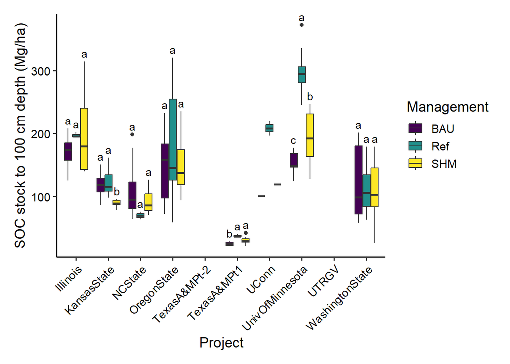

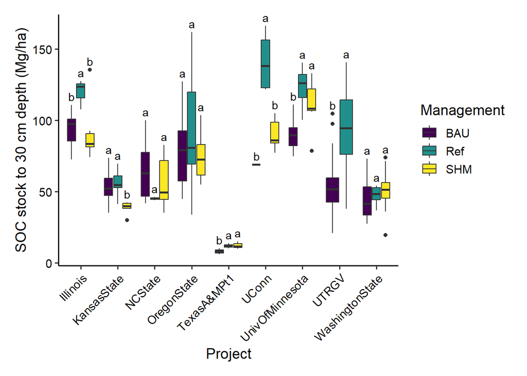

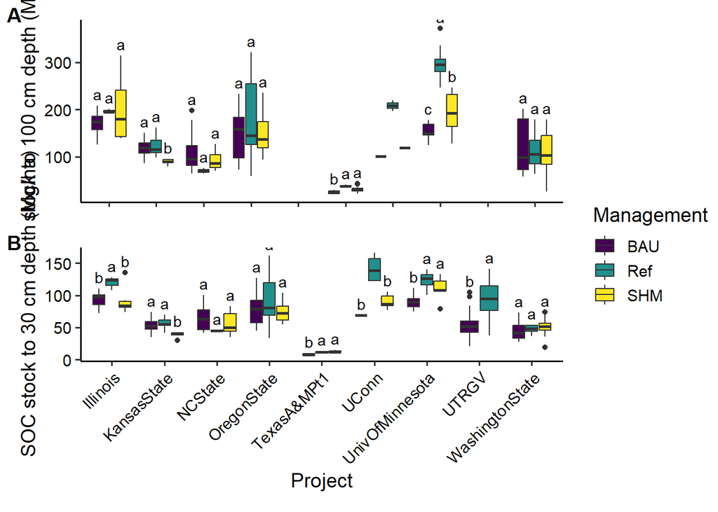

Takeaways:

- Significant variability in SOC stocks between sites (expected)
- Differences between treatments more apparent at 30 cm depth than 100 cm depth
- Reference sites are significantly higher in C at some, but not all sites (Illinois, UConn, University of Minnesota, UTRGV)
- Differences between SHM and BAU are infrequently observed

Plot alternate version with significance letters ungrouped (not shown because it is difficult to interpret):

## Fig 2 - Ribbon plot of SOC stocks by depth (continuous):

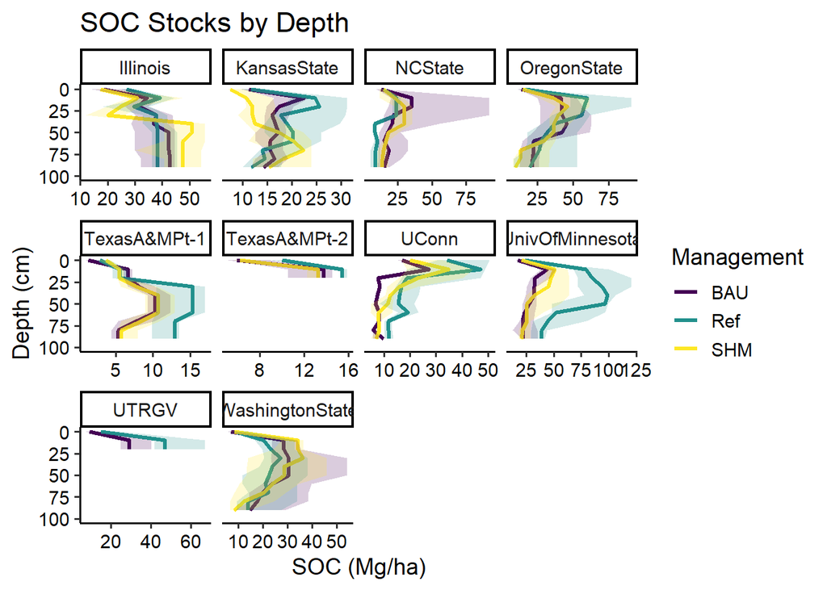

Takeaways:

- Very few projects actually showed greater SOC stocks throughout the soil profile (Minnesota, Texas A&M, UTRGV)
- Differences in C stocks tended to be most apparent at shallow depths (though see Texas A&M Pt 1 and Minnesota for exceptions where differences were greater deeper in the soil profile)